# Fundamentals of Machine Learning and Cross Validation in Caret Package

Onur Tuncay Bal

2022-07-01

# Machine Learning with Caret

In this section we will go over the fundamental aspects of the Caret package for machine learning.

Let’s work on Diamonds dataset,

Starting with linear modelling

```r
ggplot2::diamonds -> diamonds_data
lm(price~.,diamonds_data) -> diamonds_model
predict(diamonds_model,diamonds_data) -> pred

diamonds_data$price - pred -> errors

#RMSE =
rmse <- sqrt(mean(errors^2))
```

## Out of sample error measures.

Predicting over the new data. We will focus on the train-test split. This is more accurate. Pick models that perform well on new data

```r
set.seed(42)
rows <- sample(nrow(diamonds_data))
##shuffle
diamonds_data <- diamonds_data[rows,]
```

After shuffling the data lets use a split function to create our training set.

```r
diamonds_split_rule_80_20 <- round(nrow(diamonds_data)*0.8)

diamonds_training <-  diamonds_data[1:diamonds_split_rule_80_20,]

diamonds_test <- diamonds_data[(diamonds_split_rule_80_20+1):nrow(diamonds_data),]
```

We can now predict on the dataset,

```r
training_model_diamonds <- lm(price~.,diamonds_training)
predicted <- predict(training_model_diamonds,diamonds_test)
```

Let’s find out how well our model performed,

```r
#RMSE
errors_diamond_prediction <-  diamonds_test$price - predicted

sqrt(mean(errors_diamond_prediction^2)) -> rmse_diamonds
```

## Cross Validation

A different type of cross validation technique which can be accessible via caret package. Here you can see the fundamental code for cross validation in caret package,

```r
require(caret)
model_diamonds_caret <- train(price~.,diamonds_data,method = "lm", trControl = trainControl(method ="cv",number = 10, verboseIter = TRUE))
```

Don’t forget to use the traincontrol function and alter it for our purpose. Let’s check our results,

```r
model_diamonds_caret
```

```
## Linear Regression
##
## 53940 samples
##     9 predictor
##
## No pre-processing
## Resampling: Cross-Validated (10 fold)
## Summary of sample sizes: 48547, 48546, 48546, 48547, 48545, 48547, ...
## Resampling results:
##
##   RMSE      Rsquared   MAE
##   1130.633  0.9197711  740.5017
##
## Tuning parameter 'intercept' was held constant at a value of TRUE
```

We can create the same model with 5 folds cross-validation

```r
fold_5_diamonds_caret <- train(price~.,diamonds_data,method = "lm", trControl = trainControl(method = "cv",number = 5, verboseIter = TRUE))
print(fold_5_diamonds_caret)
```

```
## Linear Regression
##
## 53940 samples
##     9 predictor
##
## No pre-processing
## Resampling: Cross-Validated (5 fold)
## Summary of sample sizes: 43152, 43152, 43152, 43152, 43152
## Resampling results:
##
##   RMSE      Rsquared   MAE
##   1136.028  0.9188776  741.1295
##
## Tuning parameter 'intercept' was held constant at a value of TRUE
```

We can increase the repeats, to repeat the process with 5 cross validation schemes and find the lowers R-Squared value.

Nonetheless we should remember to change the method to “repeatedcv”

```r
fold_5_repeat_5_diamonds_caret <- train(price~.,diamonds_data,method = "lm", trControl = trainControl(method = "repeatedcv",number = 5,repeats = 5,verboseIter = TRUE))
fold_5_repeat_5_diamonds_caret
```

```
## Linear Regression
##
## 53940 samples
##     9 predictor
##
## No pre-processing
## Resampling: Cross-Validated (5 fold, repeated 5 times)
## Summary of sample sizes: 43152, 43152, 43152, 43152, 43152, 43152, ...
## Resampling results:
##
##   RMSE     Rsquared   MAE
##   1136.42  0.9188809  740.9511
##
## Tuning parameter 'intercept' was held constant at a value of TRUE
```

We can still use the predict function over the diamonds dataset,

```r
##Manual RMSE
diamonds_data$pprice <- predict(fold_5_repeat_5_diamonds_caret,diamonds_data)

errors_diamonds <- diamonds_data$pprice - diamonds_data$price

sqrt(mean(errors_diamonds^2)) -> mrmse
mrmse
```

```
## [1] 1129.843
```

## Logistic Regression in Caret Package over Sonar Data

Logistic regression is rather different from linear models, we can classify them under generalized linear models. Goal is here to determine the response variable belongs to the some category. Let’s load the Sonar data and check its structure,

```r
Sonar <- load("/Users/onurtuncaybal/Documents/Studies/Studies Summer 2022/Machine Learning with R /Machine Learning with R/Data/Sonar.RData")
```

Now let’s divide the dataset in to 60-40 split.

```r
rbind(sonar_train,sonar_test) -> sonar
#Shuffle
sampled_rows <- sample(nrow(sonar))
sonar <- sonar[sampled_rows,]
#Split
split_sonar <- round(nrow(sonar)*0.60)

sonar_train <- sonar[1:split_sonar,]
sonar_test <- sonar[(split_sonar+1):nrow(sonar),]
```

Let’s use the base package without the algorithm of the caret,

```r
sonar_model<-glm(Class~.,sonar_train,family = "binomial")
sonar_test$pred <- predict(sonar_model,sonar_test,type = "response")
```

We can create a confusion matrix to see how well our model performed, since these are probability values we should classify the probabilities.

### Confusion Matrix

```r
sonar_test$pred <- ifelse(sonar_test$pred >= 0.5,"M","R")
sonar_test$pred <- as.factor(sonar_test$pred)
confusionMatrix(sonar_test$pred,sonar_test$Class)
```

```
## Confusion Matrix and Statistics
##
##           Reference
## Prediction  M  R
##          M 19 26
##          R 27 11
##
##                Accuracy : 0.3614
##                  95% CI : (0.2588, 0.4743)
##     No Information Rate : 0.5542
##     P-Value [Acc > NIR] : 0.9999
##
##                   Kappa : -0.2889
##
##  Mcnemar's Test P-Value : 1.0000
##
##             Sensitivity : 0.4130
##             Specificity : 0.2973
##          Pos Pred Value : 0.4222
##          Neg Pred Value : 0.2895
##              Prevalence : 0.5542
##          Detection Rate : 0.2289
##    Detection Prevalence : 0.5422
##       Balanced Accuracy : 0.3552
##
##        'Positive' Class : M
##
```

```r
sonar_test$pred <- predict(sonar_model,sonar_test,type = "response")

sonar_test$pred <- as.factor(ifelse(sonar_test$pred >= 0.9, "M","R"))

confusionMatrix(sonar_test$pred,sonar_test$Class)
```

```
## Confusion Matrix and Statistics
##
##           Reference
## Prediction  M  R
##          M 18 26
##          R 28 11
##
##                Accuracy : 0.3494
##                  95% CI : (0.248, 0.4619)
##     No Information Rate : 0.5542
##     P-Value [Acc > NIR] : 0.9999
##
##                   Kappa : -0.3098
##
##  Mcnemar's Test P-Value : 0.8918
##
##             Sensitivity : 0.3913
##             Specificity : 0.2973
##          Pos Pred Value : 0.4091
##          Neg Pred Value : 0.2821
##              Prevalence : 0.5542
##          Detection Rate : 0.2169
##    Detection Prevalence : 0.5301
##       Balanced Accuracy : 0.3443
##
##        'Positive' Class : M
##
```

```r
sonar_test$pred <- predict(sonar_model,sonar_test,type = "response")
sonar_test$pred <- as.factor(ifelse(sonar_test$pred>=0.1,"M","R"))

confusionMatrix(sonar_test$pred,sonar_test$Class)
```

```
## Confusion Matrix and Statistics
##
##           Reference
## Prediction  M  R
##          M 19 26
##          R 27 11
##
##                Accuracy : 0.3614
##                  95% CI : (0.2588, 0.4743)
##     No Information Rate : 0.5542
##     P-Value [Acc > NIR] : 0.9999
##
##                   Kappa : -0.2889
##
##  Mcnemar's Test P-Value : 1.0000
##
##             Sensitivity : 0.4130
##             Specificity : 0.2973
##          Pos Pred Value : 0.4222
##          Neg Pred Value : 0.2895
##              Prevalence : 0.5542
##          Detection Rate : 0.2289
##    Detection Prevalence : 0.5422
##       Balanced Accuracy : 0.3552
##
##        'Positive' Class : M
##
```

#### Evaluating the Classification Thresholds: ROC Curve

Solutions for the different threshold probabilities and their impact. We can use ROC curves for this,

```r
require(caTools)
```

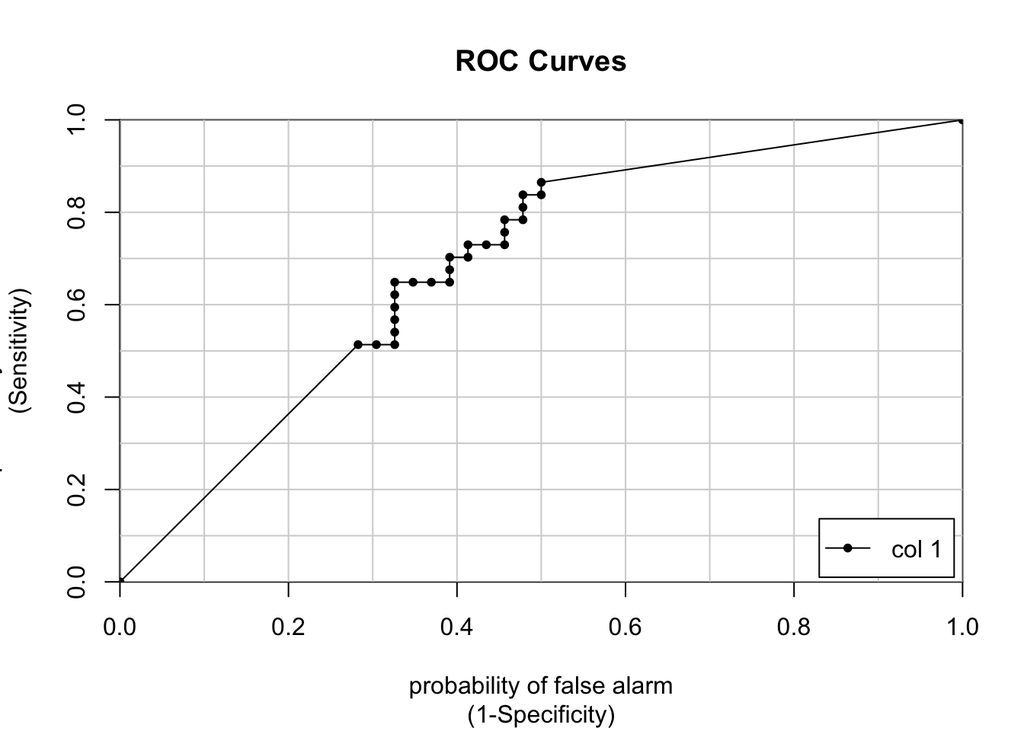

```
##              [,1]
## M vs. R 0.6856639
```

```r
sonar_test$pred <- predict(sonar_model,sonar_test,type = "response")
colAUC(sonar_test$pred,sonar_test$Class,plotROC = TRUE)
```

In here, we can see that colAUC function calculates the possible thresholds and their accuracy values, increased sensitivity means increased true positive rate. Probability of the false alarm, (1- Specificity) means that the false negatives.

Area under the ROC-Curve, AUC. We can evaluate the model performance for the Cross-Validation method with caret package.

```r
sonar_test$pred <- predict(sonar_model, sonar_test, type = "prob")
sonar_test$pred <- as.factor(ifelse(sonar_test$pred[,1]>=sonar_test$pred[,2],"M","R"))
```

We can see the model while using the caret package,

```r
print(sonar_model)
```

```
## Generalized Linear Model
##
## 125 samples
##  60 predictor
##   2 classes: 'M', 'R'
##
## No pre-processing
## Resampling: Cross-Validated (10 fold, repeated 10 times)
## Summary of sample sizes: 113, 113, 112, 113, 113, 112, ...
## Resampling results:
##
##   ROC       Sens       Spec
##   0.719623  0.6980952  0.655
```

```r
confusionMatrix(sonar_test$pred,sonar_test$Class)
```

```
## Confusion Matrix and Statistics
##
##           Reference
## Prediction  M  R
##          M 27 11
##          R 19 26
##
##                Accuracy : 0.6386
##                  95% CI : (0.5257, 0.7412)
##     No Information Rate : 0.5542
##     P-Value [Acc > NIR] : 0.07475
##
##                   Kappa : 0.2837
##
##  Mcnemar's Test P-Value : 0.20124
##
##             Sensitivity : 0.5870
##             Specificity : 0.7027
##          Pos Pred Value : 0.7105
##          Neg Pred Value : 0.5778
##              Prevalence : 0.5542
##          Detection Rate : 0.3253
##    Detection Prevalence : 0.4578
##       Balanced Accuracy : 0.6448
##
##        'Positive' Class : M
##
```

```r
predict(sonar_model,sonar_test,type = "prob")
```

```
##                M            R
## 20  9.999927e-01 7.282628e-06
## 79  2.220446e-16 1.000000e+00
## 98  1.000000e+00 2.220446e-16
## 197 1.000000e+00 2.220446e-16
## 87  2.220446e-16 1.000000e+00
## 180 1.000000e+00 2.220446e-16
## 166 1.870605e-02 9.812940e-01
## 122 1.000000e+00 2.220446e-16
## 140 2.220446e-16 1.000000e+00
## 10  2.220446e-16 1.000000e+00
## 51  2.220446e-16 1.000000e+00
## 66  2.220446e-16 1.000000e+00
## 44  2.220446e-16 1.000000e+00
## 16  2.220446e-16 1.000000e+00
```

[output cut: 69 more lines]